# Supervised Learning - Foundations Project: ReCell

#### The most ran os on the devices is Android

```python
#Percentage of the used device market dominated by Android devices
(3214/3454)*100
```

```
93.05153445280834
```

##### 93% of the used device market are dominated by Android

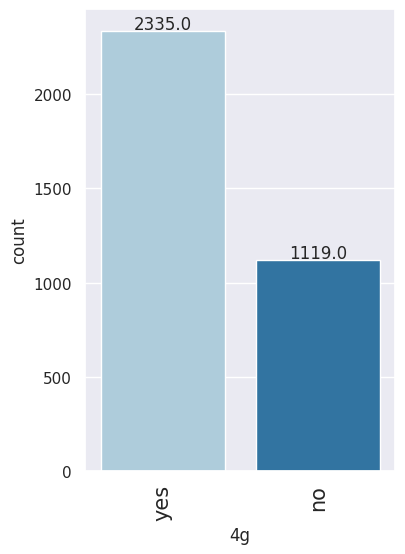

```python
#4g
labeled_barplot(data, "4g")
```

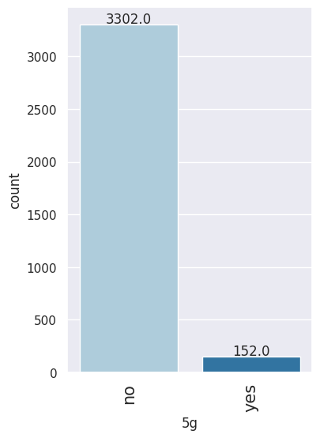

```python
#5g
labeled_barplot(data, "5g")
```

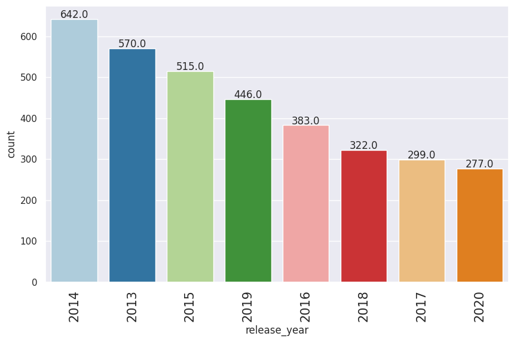

```python
#release_year
labeled_barplot(data, "release_year")
```

##### More models were released in 2014, and the least was released in 2020.

### Bivariate Analysis

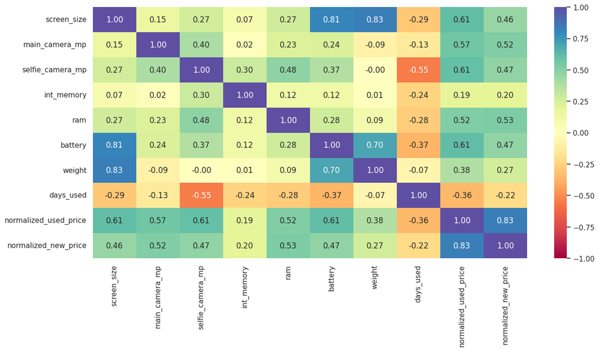

```python
#Correlation Check
cols_list = data.select_dtypes(include=np.number).columns.tolist()
# dropping release_year as it is a temporal variable
cols_list.remove("release_year")

plt.figure(figsize=(15, 7))
sns.heatmap(
    data[cols_list].corr(), annot=True, vmin=-1, vmax=1, fmt=".2f", cmap="Spectral"
)
plt.show()
```

##### There is a high correlation between screen size and weight of the phone.

##### There is a high correlation between screen size and battery of the phone.

##### There is a high correlation between the battery and weight of the phone.

##### There is a high correlation between normalized used price and normalized new price.

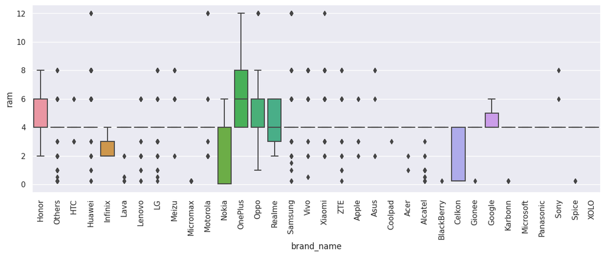

```python
#Relation between Ram and phone Brand
plt.figure(figsize=(15, 5))
sns.boxplot(data, x="brand_name", y="ram")
plt.xticks(rotation=90)
plt.show()
```

##### OnePlus brand has phones with highest brand followed Honor, Oppo, Rralme and Google brands.

```python
#Relation between batteries and device weights
data_large_battery = data[data.battery > 4500]
data_large_battery.shape
```

```
(341, 15)
```

##### There are 341 devices with batteries that weighs more than 4500mAh

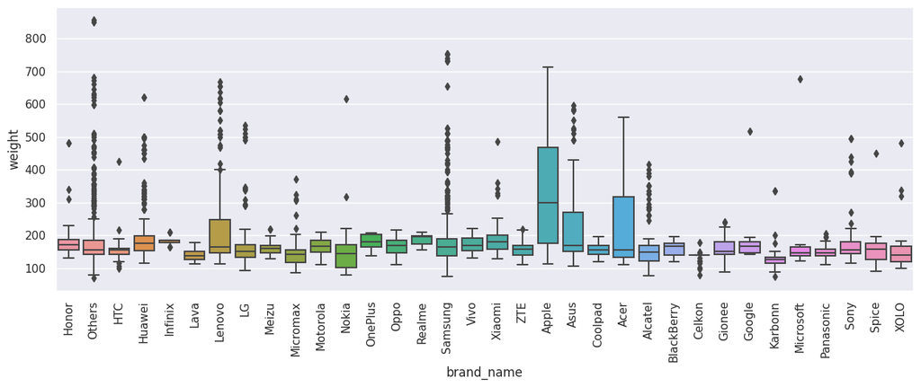

```python
plt.figure(figsize=(15, 5))
sns.boxplot(data, x="brand_name", y="weight")
plt.xticks(rotation=90)
plt.show()
```

##### Apple brands has the largest weights on average campared to other brand devices. Followed by Acer, Asus, and Lenovo.

```python
#Relation Between Screen Size And Brand
data_large_screen = data[data.screen_size > 6 * 2.54] #screen size larger than 6 inches
data_large_screen.shape
```

```
(1099, 15)
```

##### There are 1099 devices with screen sizes larger than 6 inches

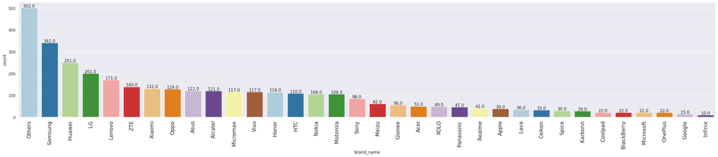

```python
labeled_barplot(data, "brand_name")
```

```python
#Relation between selfie_cameras and brands
data_selfie_camera = data[data.selfie_camera_mp > 8] #Selfie cameras greater than 8MP
data_selfie_camera.shape
```

```
(655, 15)
```

##### There are 655 devices with selfie cameras greater than 8MP

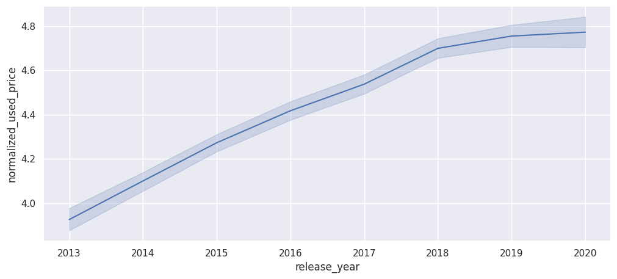

```python
#Relation between used devices and years
plt.figure(figsize=(12, 5))
sns.lineplot(data, y="normalized_used_price", x="release_year") ## Complete the code to create a lineplot for release year and used price
plt.show()
```

###### There is a high correlation between normalized used device and the release year

## Data Preprocessing

- Missing value treatment
- Feature engineering (if needed)
- Outlier detection and treatment (if needed)
- Preparing data for modeling
- Any other preprocessing steps (if needed)

#### Feature Engineering

```python
#Creating a new column form release year to to year_since_released and giving the year for data collection to be 2021
data["years_since_release"] = 2021 - data["release_year"]
data.drop("release_year", axis=1, inplace=True)
data["years_since_release"].describe()
```

```
count    3454.000000
mean        5.034742
std         2.298455
min         1.000000
25%         3.000000
50%         5.500000
75%         7.000000
max         8.000000
Name: years_since_release, dtype: float64
```

##### Checking For Outliers

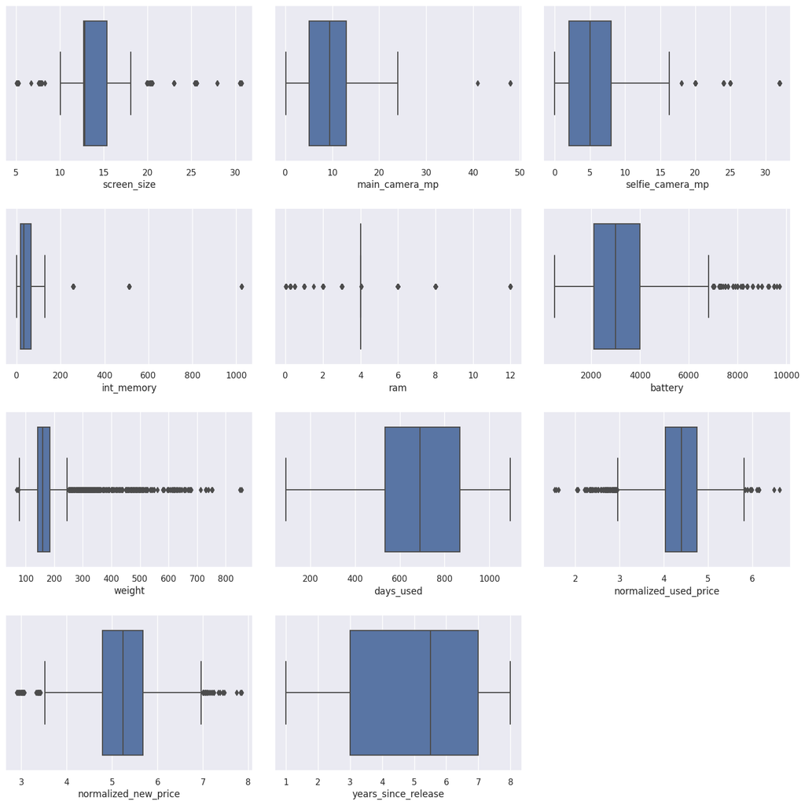

```python
# outlier detection using boxplot
num_cols = data.select_dtypes(include=np.number).columns.tolist()

plt.figure(figsize=(15, 15))

for i, variable in enumerate(num_cols):
    plt.subplot(4, 3, i + 1)
    sns.boxplot(data=data, x=variable)
    plt.tight_layout(pad=2)
```

#### Data Preparation for modeling

```python
data.head()
```

|  | brand_name | os | screen_size | 4g | 5g | main_camera_mp | selfie_camera_mp | int_memory | ram | battery | weight | days_used | normalized_used_price | normalized_new_price | years_since_release |
| --- | --- | --- | --- | --- | --- | --- | --- | --- | --- | --- | --- | --- | --- | --- | --- |
| 0 | Honor | Android | 14.50 | yes | no | 13.0 | 5.0 | 64.0 | 3.0 | 3020.0 | 146.0 | 127 | 4.307572 | 4.715100 | 1 |
| 1 | Honor | Android | 17.30 | yes | yes | 13.0 | 16.0 | 128.0 | 8.0 | 4300.0 | 213.0 | 325 | 5.162097 | 5.519018 | 1 |
| 2 | Honor | Android | 16.69 | yes | yes | 13.0 | 8.0 | 128.0 | 8.0 | 4200.0 | 213.0 | 162 | 5.111084 | 5.884631 | 1 |
| 3 | Honor | Android | 25.50 | yes | yes | 13.0 | 8.0 | 64.0 | 6.0 | 7250.0 | 480.0 | 345 | 5.135387 | 5.630961 | 1 |
| 4 | Honor | Android | 15.32 | yes | no | 13.0 | 8.0 | 64.0 | 3.0 | 5000.0 | 185.0 | 293 | 4.389995 | 4.947837 | 1 |

```python
#Defining the dependent and independent variables
X =data.drop(["normalized_used_price"], axis=1)
y =data[["normalized_used_price"]]

print(X.head())
print()
print(y.head())
```

```
  brand_name       os  screen_size   4g   5g  main_camera_mp  \
0      Honor  Android        14.50  yes   no            13.0
1      Honor  Android        17.30  yes  yes            13.0
2      Honor  Android        16.69  yes  yes            13.0
3      Honor  Android        25.50  yes  yes            13.0
4      Honor  Android        15.32  yes   no            13.0

   selfie_camera_mp  int_memory  ram  battery  weight  days_used  \
0               5.0        64.0  3.0   3020.0   146.0        127
1              16.0       128.0  8.0   4300.0   213.0        325
2               8.0       128.0  8.0   4200.0   213.0        162
3               8.0        64.0  6.0   7250.0   480.0        345
4               8.0        64.0  3.0   5000.0   185.0        293

   normalized_new_price  years_since_release
0              4.715100                    1
1              5.519018                    1
2              5.884631                    1
3              5.630961                    1
4              4.947837                    1

   normalized_used_price
0               4.307572
1               5.162097
2               5.111084
3               5.135387
4               4.389995
```

```python
#Adding the intercept to data
X = sm.add_constant(X)
```

```python
# creating dummy variables
X = pd.get_dummies(
    X,
    columns=X.select_dtypes(include=["object", "category"]).columns.tolist(),
    drop_first=True,
)

X.head()
```

|  | const | screen_size | main_camera_mp | selfie_camera_mp | int_memory | ram | battery | weight | days_used | normalized_new_price | ... | brand_name_Spice | brand_name_Vivo | brand_name_XOLO | brand_name_Xiaomi | brand_name_ZTE | os_Others | os_Windows | os_iOS | 4g_yes | 5g_yes |
| --- | --- | --- | --- | --- | --- | --- | --- | --- | --- | --- | --- | --- | --- | --- | --- | --- | --- | --- | --- | --- | --- |
| 0 | 1.0 | 14.50 | 13.0 | 5.0 | 64.0 | 3.0 | 3020.0 | 146.0 | 127 | 4.715100 | ... | 0 | 0 | 0 | 0 | 0 | 0 | 0 | 0 | 1 | 0 |
| 1 | 1.0 | 17.30 | 13.0 | 16.0 | 128.0 | 8.0 | 4300.0 | 213.0 | 325 | 5.519018 | ... | 0 | 0 | 0 | 0 | 0 | 0 | 0 | 0 | 1 | 1 |
| 2 | 1.0 | 16.69 | 13.0 | 8.0 | 128.0 | 8.0 | 4200.0 | 213.0 | 162 | 5.884631 | ... | 0 | 0 | 0 | 0 | 0 | 0 | 0 | 0 | 1 | 1 |
| 3 | 1.0 | 25.50 | 13.0 | 8.0 | 64.0 | 6.0 | 7250.0 | 480.0 | 345 | 5.630961 | ... | 0 | 0 | 0 | 0 | 0 | 0 | 0 | 0 | 1 | 1 |
| 4 | 1.0 | 15.32 | 13.0 | 8.0 | 64.0 | 3.0 | 5000.0 | 185.0 | 293 | 4.947837 | ... | 0 | 0 | 0 | 0 | 0 | 0 | 0 | 0 | 1 | 0 |

5 rows × 49 columns

```python
# splitting the data in 70:30 ratio for train to test data

x_train, x_test, y_train, y_test =train_test_split(
    X, y, test_size=0.30, random_state=1
)
```

```python
print("Number of rows in train data =", x_train.shape[0])
print("Number of rows in test data =", x_test.shape[0])
```

```
Number of rows in train data = 2417
Number of rows in test data = 1037
```

## Model Building - Linear Regression

```python
#Making the linear model using statsmodels OLS and printing the model summary.
olsmodel1 = sm.OLS(y_train, x_train).fit()
print(olsmodel1.summary())
```

```
                              OLS Regression Results
=================================================================================
Dep. Variable:     normalized_used_price   R-squared:                       0.845
Model:                               OLS   Adj. R-squared:                  0.842
Method:                    Least Squares   F-statistic:                     268.9
Date:                   Fri, 21 Jul 2023   Prob (F-statistic):               0.00
Time:                           19:40:02   Log-Likelihood:                 124.63
No. Observations:                   2417   AIC:                            -151.3
Df Residuals:                       2368   BIC:                             132.5
Df Model:                             48
Covariance Type:               nonrobust
=========================================================================================
                            coef    std err          t      P>|t|      [0.025      0.975]
-----------------------------------------------------------------------------------------
const                     1.3251      0.071     18.575      0.000       1.185       1.465
screen_size               0.0243      0.003      7.150      0.000       0.018       0.031
main_camera_mp            0.0206      0.001     13.852      0.000       0.018       0.024
selfie_camera_mp          0.0135      0.001     12.043      0.000       0.011       0.016
int_memory                0.0001   6.97e-05      1.575      0.115   -2.69e-05       0.000
ram                       0.0239      0.005      4.643      0.000       0.014       0.034
battery               -1.628e-05   7.27e-06     -2.240      0.025   -3.05e-05   -2.03e-06
weight                    0.0010      0.000      7.474      0.000       0.001       0.001
days_used              3.601e-05   3.09e-05      1.166      0.244   -2.46e-05    9.66e-05
normalized_new_price      0.4305      0.012     35.055      0.000       0.406       0.455
years_since_release      -0.0243      0.005     -5.333      0.000      -0.033      -0.015
brand_name_Alcatel        0.0155      0.048      0.326      0.744      -0.078       0.109
brand_name_Apple         -0.0101      0.147     -0.068      0.945      -0.298       0.278
brand_name_Asus           0.0182      0.048      0.380      0.704      -0.076       0.112
brand_name_BlackBerry    -0.0366      0.070     -0.521      0.602      -0.174       0.101
brand_name_Celkon        -0.0438      0.066     -0.662      0.508      -0.174       0.086
brand_name_Coolpad        0.0348      0.073      0.477      0.633      -0.108       0.178
brand_name_Gionee         0.0453      0.058      0.784      0.433      -0.068       0.158
brand_name_Google        -0.0322      0.085     -0.381      0.703      -0.198       0.134
brand_name_HTC           -0.0120      0.048     -0.249      0.803      -0.106       0.082
brand_name_Honor          0.0264      0.049      0.538      0.591      -0.070       0.123
brand_name_Huawei        -0.0062      0.044     -0.139      0.890      -0.093       0.081
brand_name_Infinix        0.1281      0.093      1.375      0.169      -0.055       0.311
brand_name_Karbonn        0.0959      0.067      1.429      0.153      -0.036       0.227
brand_name_LG            -0.0142      0.045     -0.314      0.753      -0.103       0.075
brand_name_Lava           0.0311      0.062      0.499      0.618      -0.091       0.153
```

[output cut: 19 more lines]

```
os_Windows               -0.0191      0.045     -0.423      0.672      -0.108       0.069
os_iOS                   -0.0595      0.146     -0.406      0.685      -0.347       0.228
4g_yes                    0.0510      0.016      3.210      0.001       0.020       0.082
5g_yes                   -0.0511      0.032     -1.613      0.107      -0.113       0.011
==============================================================================
Omnibus:                      220.192   Durbin-Watson:                   1.905
Prob(Omnibus):                  0.000   Jarque-Bera (JB):              415.533
Skew:                          -0.612   Prob(JB):                     5.86e-91
Kurtosis:                       4.621   Cond. No.                     1.78e+05
==============================================================================

Notes:
[1] Standard Errors assume that the covariance matrix of the errors is correctly specified.
[2] The condition number is large, 1.78e+05. This might indicate that there are
strong multicollinearity or other numerical problems.
```

## Model Performance Check

```python
#Checking the performance of the model using different metrics
# function to compute adjusted R-squared
def adj_r2_score(predictors, targets, predictions):
    r2 = r2_score(targets, predictions)
    n = predictors.shape[0]
    k = predictors.shape[1]
    return 1 - ((1 - r2) * (n - 1) / (n - k - 1))


# function to compute MAPE
def mape_score(targets, predictions):
    return np.mean(np.abs(targets - predictions) / targets) * 100


# function to compute different metrics to check performance of a regression model
def model_performance_regression(model, predictors, target):
    """
    Function to compute different metrics to check regression model performance

    model: regressor
    predictors: independent variables
    target: dependent variable
    """

    # predicting using the independent variables
    pred = model.predict(predictors)

    r2 = r2_score(target, pred)  # to compute R-squared
    adjr2 = adj_r2_score(predictors, target, pred)  # to compute adjusted R-squared
    rmse = np.sqrt(mean_squared_error(target, pred))  # to compute RMSE
    mae = mean_absolute_error(target, pred)  # to compute MAE
    mape = mape_score(target, pred)  # to compute MAPE

    # creating a dataframe of metrics
    df_perf = pd.DataFrame(
        {
            "RMSE": rmse,
            "MAE": mae,
            "R-squared": r2,
            "Adj. R-squared": adjr2,
            "MAPE": mape,
        },
        index=[0],
    )

    return df_perf
```

```python
# checking model performance on train set (seen 70% data)
print("Training Performance\n")
olsmodel1_train_perf = model_performance_regression(olsmodel1, x_train, y_train)
olsmodel1_train_perf
```

```
Training Performance
```

|  | RMSE | MAE | R-squared | Adj. R-squared | MAPE |
| --- | --- | --- | --- | --- | --- |
| 0 | 0.22981 | 0.18025 | 0.844986 | 0.841777 | NaN |

```python
# checking model performance on test set (seen 30% data)
print("Test Performance\n")
olsmodel1_test_perf = model_performance_regression(olsmodel1, x_test, y_test)
olsmodel1_test_perf
```

```
Test Performance
```

|  | RMSE | MAE | R-squared | Adj. R-squared | MAPE |
| --- | --- | --- | --- | --- | --- |
| 0 | 0.238272 | 0.184283 | 0.842593 | 0.834779 | NaN |

## Checking Linear Regression Assumptions

- In order to make statistical inferences from a linear regression model, it is important to ensure that the assumptions of linear regression are satisfied.

#### Checking for the following Linear Regression assumptions:

###### No Multicollinearity

###### Linearity of variables

###### Independence of error terms

###### Normality of error terms

###### No Heteroscedasticity

#### TEST FOR MULTICOLLINEARITY

###### Test for multicollinearity using VIF.

##### General Rule of thumb:

###### If VIF is 1 then there is no correlation between the kth predictor and the remaining predictor variables.

###### If VIF exceeds 5 or is close to exceeding 5, we say there is moderate multicollinearity.

###### If VIF is 10 or exceeding 10, it shows signs of high multicollinearity.

###### Defining a function to check VIF.

```python
#Defining a function to check VIF.

def checking_vif(predictors):
    vif = pd.DataFrame()
    vif["feature"] = predictors.columns

    # calculating VIF for each feature
    vif["VIF"] = [
        variance_inflation_factor(predictors.values, i)
        for i in range(len(predictors.columns))
    ]
    return vif
```

```python
checking_vif(x_train)
```

|  | feature | VIF |
| --- | --- | --- |
| 0 | const | 228.192463 |
| 1 | screen_size | 7.674511 |
| 2 | main_camera_mp | 2.184339 |
| 3 | selfie_camera_mp | 2.809894 |
| 4 | int_memory | 1.362034 |
| 5 | ram | 2.257453 |
| 6 | battery | 4.076281 |
| 7 | weight | 6.376012 |
| 8 | days_used | 2.667672 |
| 9 | normalized_new_price | 3.128734 |
| 10 | years_since_release | 4.885974 |
| 11 | brand_name_Alcatel | 3.405652 |
| 12 | brand_name_Apple | 13.056484 |
| 13 | brand_name_Asus | 3.330899 |
| 14 | brand_name_BlackBerry | 1.632460 |
| 15 | brand_name_Celkon | 1.774129 |
| 16 | brand_name_Coolpad | 1.466826 |
| 17 | brand_name_Gionee | 1.951268 |
| 18 | brand_name_Google | 1.321990 |
| 19 | brand_name_HTC | 3.409872 |
| 20 | brand_name_Honor | 3.344435 |
| 21 | brand_name_Huawei | 5.985521 |
| 22 | brand_name_Infinix | 1.283357 |
| 23 | brand_name_Karbonn | 1.573378 |
| 24 | brand_name_LG | 4.849084 |
| 25 | brand_name_Lava | 1.711561 |
| 26 | brand_name_Lenovo | 4.559029 |
| 27 | brand_name_Meizu | 2.174541 |
| 28 | brand_name_Micromax | 3.363500 |
| 29 | brand_name_Microsoft | 1.869285 |
| 30 | brand_name_Motorola | 3.263741 |
| 31 | brand_name_Nokia | 3.471216 |
| 32 | brand_name_OnePlus | 1.436008 |
| 33 | brand_name_Oppo | 3.971384 |
| 34 | brand_name_Others | 9.710624 |
| 35 | brand_name_Panasonic | 2.105801 |
| 36 | brand_name_Realme | 1.931405 |
| 37 | brand_name_Samsung | 7.539609 |
| 38 | brand_name_Sony | 2.935212 |
| 39 | brand_name_Spice | 1.688794 |
| 40 | brand_name_Vivo | 3.648678 |
| 41 | brand_name_XOLO | 2.136613 |
| 42 | brand_name_Xiaomi | 3.714132 |
| 43 | brand_name_ZTE | 3.796532 |
| 44 | os_Others | 1.855951 |
| 45 | os_Windows | 1.595325 |
| 46 | os_iOS | 11.784282 |
| 47 | 4g_yes | 2.476262 |
| 48 | 5g_yes | 1.834183 |

#### Removing Multicollinearity (if needed)

##### To remove multicollinearity

###### Drop every column one by one that has a VIF score greater than 5.

###### Look at the adjusted R-squared and RMSE of all these models.

###### Drop the variable that makes the least change in adjusted R-squared.

###### Check the VIF scores again.

###### Continue till you get all VIF scores under 5.

###### Defining a function that will help us do this.

```python
def treating_multicollinearity(predictors, target, high_vif_columns):
    """
    Checking the effect of dropping the columns showing high multicollinearity
    on model performance (adj. R-squared and RMSE)

    predictors: independent variables
    target: dependent variable
    high_vif_columns: columns having high VIF
    """
    # empty lists to store adj. R-squared and RMSE values
    adj_r2 = []
    rmse = []

    # build ols models by dropping one of the high VIF columns at a time
    # store the adjusted R-squared and RMSE in the lists defined previously
    for cols in high_vif_columns:
        # defining the new train set
        train = predictors.loc[:, ~predictors.columns.str.startswith(cols)]

        # create the model
        olsmodel = sm.OLS(target, train).fit()

        # adding adj. R-squared and RMSE to the lists
        adj_r2.append(olsmodel.rsquared_adj)
        rmse.append(np.sqrt(olsmodel.mse_resid))

    # creating a dataframe for the results
    temp = pd.DataFrame(
        {
            "col": high_vif_columns,
            "Adj. R-squared after_dropping col": adj_r2,
            "RMSE after dropping col": rmse,
        }
    ).sort_values(by="Adj. R-squared after_dropping col", ascending=False)
    temp.reset_index(drop=True, inplace=True)

    return temp
```

```python
col_list = ["brand_name_Samsung","os_iOS","screen_size","weight","brand_name_Apple","brand_name_Huawei","brand_name_Others"]

res = treating_multicollinearity(x_train, y_train, col_list) ## Complete the code to check the effect on model performance after dropping specified columns from train data
res
```

|  | col | Adj. R-squared after_dropping col | RMSE after dropping col |
| --- | --- | --- | --- |
| 0 | brand_name_Apple | 0.841910 | 0.232127 |
| 1 | brand_name_Huawei | 0.841909 | 0.232127 |
| 2 | brand_name_Others | 0.841908 | 0.232128 |
| 3 | os_iOS | 0.841899 | 0.232135 |
| 4 | brand_name_Samsung | 0.841874 | 0.232153 |
| 5 | screen_size | 0.838497 | 0.234619 |
| 6 | weight | 0.838180 | 0.234849 |

```python
x_train2=x_train.drop(["brand_name_Apple"], axis=1)
olsmod_1=sm.OLS(y_train,x_train2)
olsres_1=olsmod_1.fit()
print(
    "R-squared:",
    np.round(olsres_1.rsquared,3),
    "\nAdjusted R-squared:",
    np.round(olsres_1.rsquared_adj,3),
)
```

```
R-squared: 0.845
Adjusted R-squared: 0.842
```

```python
x_train3=x_train.drop(["brand_name_Huawei"], axis=1)
olsmod_2=sm.OLS(y_train,x_train3)
olsres_2=olsmod_2.fit()
print(
    "R-squared:",
    np.round(olsres_2.rsquared,3),
    "\nAdjusted R-squared:",
    np.round(olsres_2.rsquared_adj,3),
)
```

```
R-squared: 0.845
Adjusted R-squared: 0.842
```

```python
x_train4=x_train.drop(["brand_name_Others"], axis=1)
olsmod_3=sm.OLS(y_train,x_train4)
olsres_3=olsmod_3.fit()
print(
    "R-squared:",
    np.round(olsres_3.rsquared,3),
    "\nAdjusted R-squared:",
    np.round(olsres_3.rsquared_adj,3),
)
```

```
R-squared: 0.845
Adjusted R-squared: 0.842
```

```python
x_train=x_train.drop(["brand_name_Apple"], axis=1)
```

```python
olsmodel1 = sm.OLS(y_train, x_train).fit()
print(olsmodel1.summary())
```

```
                              OLS Regression Results
=================================================================================
Dep. Variable:     normalized_used_price   R-squared:                       0.845
Model:                               OLS   Adj. R-squared:                  0.842
Method:                    Least Squares   F-statistic:                     274.8
Date:                   Fri, 21 Jul 2023   Prob (F-statistic):               0.00
Time:                           20:09:31   Log-Likelihood:                 124.63
No. Observations:                   2417   AIC:                            -153.3
Df Residuals:                       2369   BIC:                             124.7
Df Model:                             47
Covariance Type:               nonrobust
=========================================================================================
                            coef    std err          t      P>|t|      [0.025      0.975]
-----------------------------------------------------------------------------------------
const                     1.3249      0.071     18.595      0.000       1.185       1.465
screen_size               0.0243      0.003      7.163      0.000       0.018       0.031
main_camera_mp            0.0206      0.001     13.856      0.000       0.018       0.024
selfie_camera_mp          0.0135      0.001     12.097      0.000       0.011       0.016
int_memory                0.0001   6.97e-05      1.575      0.115   -2.69e-05       0.000
ram                       0.0238      0.005      4.649      0.000       0.014       0.034
battery               -1.629e-05   7.27e-06     -2.243      0.025   -3.05e-05   -2.05e-06
weight                    0.0010      0.000      7.479      0.000       0.001       0.001
days_used              3.604e-05   3.09e-05      1.167      0.243   -2.45e-05    9.66e-05
normalized_new_price      0.4304      0.012     35.151      0.000       0.406       0.454
years_since_release      -0.0242      0.005     -5.336      0.000      -0.033      -0.015
brand_name_Alcatel        0.0163      0.046      0.351      0.726      -0.075       0.107
brand_name_Asus           0.0190      0.047      0.408      0.684      -0.072       0.110
brand_name_BlackBerry    -0.0356      0.069     -0.519      0.604      -0.170       0.099
brand_name_Celkon        -0.0431      0.065     -0.660      0.510      -0.171       0.085
brand_name_Coolpad        0.0355      0.072      0.493      0.622      -0.106       0.177
brand_name_Gionee         0.0460      0.057      0.810      0.418      -0.065       0.157
brand_name_Google        -0.0314      0.084     -0.375      0.708      -0.195       0.133
brand_name_HTC           -0.0113      0.047     -0.240      0.810      -0.103       0.081
brand_name_Honor          0.0272      0.048      0.569      0.569      -0.067       0.121
brand_name_Huawei        -0.0054      0.043     -0.125      0.900      -0.090       0.079
brand_name_Infinix        0.1289      0.092      1.394      0.163      -0.052       0.310
brand_name_Karbonn        0.0965      0.066      1.452      0.147      -0.034       0.227
brand_name_LG            -0.0135      0.044     -0.307      0.759      -0.100       0.073
brand_name_Lava           0.0317      0.062      0.515      0.606      -0.089       0.152
brand_name_Lenovo         0.0458      0.044      1.045      0.296      -0.040       0.132
```

[output cut: 18 more lines]

```
os_Windows               -0.0192      0.045     -0.426      0.670      -0.108       0.069
os_iOS                   -0.0686      0.059     -1.165      0.244      -0.184       0.047
4g_yes                    0.0510      0.016      3.209      0.001       0.020       0.082
5g_yes                   -0.0509      0.032     -1.613      0.107      -0.113       0.011
==============================================================================
Omnibus:                      220.169   Durbin-Watson:                   1.905
Prob(Omnibus):                  0.000   Jarque-Bera (JB):              415.634
Skew:                          -0.612   Prob(JB):                     5.57e-91
Kurtosis:                       4.621   Cond. No.                     1.70e+05
==============================================================================

Notes:
[1] Standard Errors assume that the covariance matrix of the errors is correctly specified.
[2] The condition number is large, 1.7e+05. This might indicate that there are
strong multicollinearity or other numerical problems.
```

```python
checking_vif(x_train2)
```

|  | feature | VIF |
| --- | --- | --- |
| 0 | const | 227.731995 |
| 1 | screen_size | 7.640654 |
| 2 | main_camera_mp | 2.183464 |
| 3 | selfie_camera_mp | 2.788621 |
| 4 | int_memory | 1.362021 |
| 5 | ram | 2.249288 |
| 6 | battery | 4.074299 |
| 7 | weight | 6.373394 |
| 8 | days_used | 2.667151 |
| 9 | normalized_new_price | 3.112180 |
| 10 | years_since_release | 4.877330 |
| 11 | brand_name_Alcatel | 3.230692 |
| 12 | brand_name_Asus | 3.143789 |
| 13 | brand_name_BlackBerry | 1.561180 |
| 14 | brand_name_Celkon | 1.731124 |
| 15 | brand_name_Coolpad | 1.435693 |
| 16 | brand_name_Gionee | 1.886313 |
| 17 | brand_name_Google | 1.293290 |
| 18 | brand_name_HTC | 3.239891 |
| 19 | brand_name_Honor | 3.162991 |
| 20 | brand_name_Huawei | 5.582613 |
| 21 | brand_name_Infinix | 1.264788 |
| 22 | brand_name_Karbonn | 1.543842 |
| 23 | brand_name_LG | 4.564696 |
| 24 | brand_name_Lava | 1.670889 |
| 25 | brand_name_Lenovo | 4.291501 |
| 26 | brand_name_Meizu | 2.087841 |
| 27 | brand_name_Micromax | 3.214066 |
| 28 | brand_name_Microsoft | 1.834974 |
| 29 | brand_name_Motorola | 3.098772 |
| 30 | brand_name_Nokia | 3.256317 |
| 31 | brand_name_OnePlus | 1.401702 |
| 32 | brand_name_Oppo | 3.763256 |
| 33 | brand_name_Others | 9.074347 |
| 34 | brand_name_Panasonic | 2.030825 |
| 35 | brand_name_Realme | 1.864232 |
| 36 | brand_name_Samsung | 6.991224 |
| 37 | brand_name_Sony | 2.790864 |
| 38 | brand_name_Spice | 1.655305 |
| 39 | brand_name_Vivo | 3.444836 |
| 40 | brand_name_XOLO | 2.068534 |
| 41 | brand_name_Xiaomi | 3.507415 |
| 42 | brand_name_ZTE | 3.602864 |
| 43 | os_Others | 1.736124 |
| 44 | os_Windows | 1.593044 |
| 45 | os_iOS | 1.908613 |
| 46 | 4g_yes | 2.475351 |
| 47 | 5g_yes | 1.826122 |

```python
x_train=x_train.drop(["brand_name_Huawei"], axis=1)
```

```python
checking_vif(x_train3)
```

[output not shown]

```python
checking_vif(x_train4)
```

|  | feature | VIF |
| --- | --- | --- |
| 0 | const | 153.392115 |
| 1 | screen_size | 7.628609 |
| 2 | main_camera_mp | 2.182534 |
| 3 | selfie_camera_mp | 2.809881 |
| 4 | int_memory | 1.361390 |
| 5 | ram | 2.256408 |
| 6 | battery | 4.076277 |
| 7 | weight | 6.356152 |
| 8 | days_used | 2.667190 |
| 9 | normalized_new_price | 3.128732 |
| 10 | years_since_release | 4.883847 |
| 11 | brand_name_Alcatel | 1.219538 |
| 12 | brand_name_Apple | 12.200975 |
| 13 | brand_name_Asus | 1.203491 |
| 14 | brand_name_BlackBerry | 1.131725 |
| 15 | brand_name_Celkon | 1.174132 |
| 16 | brand_name_Coolpad | 1.053209 |
| 17 | brand_name_Gionee | 1.091268 |
| 18 | brand_name_Google | 1.045995 |
| 19 | brand_name_HTC | 1.222045 |
| 20 | brand_name_Honor | 1.287239 |
| 21 | brand_name_Huawei | 1.509829 |
| 22 | brand_name_Infinix | 1.061016 |
| 23 | brand_name_Karbonn | 1.073642 |
| 24 | brand_name_LG | 1.346493 |
| 25 | brand_name_Lava | 1.071085 |
| 26 | brand_name_Lenovo | 1.301405 |
| 27 | brand_name_Meizu | 1.132448 |
| 28 | brand_name_Micromax | 1.227904 |
| 29 | brand_name_Microsoft | 1.494871 |
| 30 | brand_name_Motorola | 1.250445 |
| 31 | brand_name_Nokia | 1.494332 |
| 32 | brand_name_OnePlus | 1.081428 |
| 33 | brand_name_Oppo | 1.375003 |
| 34 | brand_name_Panasonic | 1.106868 |
| 35 | brand_name_Realme | 1.158677 |
| 36 | brand_name_Samsung | 1.590678 |
| 37 | brand_name_Sony | 1.207584 |
| 38 | brand_name_Spice | 1.081017 |
| 39 | brand_name_Vivo | 1.326676 |
| 40 | brand_name_XOLO | 1.113297 |
| 41 | brand_name_Xiaomi | 1.313800 |
| 42 | brand_name_ZTE | 1.263584 |
| 43 | os_Others | 1.855712 |
| 44 | os_Windows | 1.593917 |
| 45 | os_iOS | 11.783776 |
| 46 | 4g_yes | 2.470493 |
| 47 | 5g_yes | 1.834112 |

```python
olsmodel3 = sm.OLS(y_train, x_train).fit()
print(olsmodel3.summary())
```

[output not shown]

[output cut: 19 more lines]

[output not shown]

```python
x_train5=x_train.drop(["weight"], axis=1)
olsmod_4=sm.OLS(y_train,x_train2)
olsres_4=olsmod_4.fit()
print(
    "R-squared:",
    np.round(olsres_4.rsquared,3),
    "\nAdjusted R-squared:",
    np.round(olsres_4.rsquared_adj,3),
)
```

```
R-squared: 0.845
Adjusted R-squared: 0.842
```

```python
olsmodel4 = sm.OLS(y_train, x_train).fit()
print(olsmodel4.summary())
```

```
                              OLS Regression Results
=================================================================================
Dep. Variable:     normalized_used_price   R-squared:                       0.845
Model:                               OLS   Adj. R-squared:                  0.842
Method:                    Least Squares   F-statistic:                     280.8
Date:                   Fri, 21 Jul 2023   Prob (F-statistic):               0.00
Time:                           20:15:21   Log-Likelihood:                 124.62
No. Observations:                   2417   AIC:                            -155.2
Df Residuals:                       2370   BIC:                             116.9
Df Model:                             46
Covariance Type:               nonrobust
=========================================================================================
                            coef    std err          t      P>|t|      [0.025      0.975]
-----------------------------------------------------------------------------------------
const                     1.3203      0.061     21.563      0.000       1.200       1.440
screen_size               0.0243      0.003      7.175      0.000       0.018       0.031
main_camera_mp            0.0206      0.001     13.859      0.000       0.018       0.024
selfie_camera_mp          0.0135      0.001     12.114      0.000       0.011       0.016
int_memory                0.0001   6.96e-05      1.572      0.116   -2.71e-05       0.000
ram                       0.0238      0.005      4.653      0.000       0.014       0.034
battery                -1.63e-05   7.26e-06     -2.245      0.025   -3.05e-05   -2.06e-06
weight                    0.0010      0.000      7.480      0.000       0.001       0.001
days_used               3.61e-05   3.09e-05      1.169      0.242   -2.44e-05    9.66e-05
normalized_new_price      0.4304      0.012     35.162      0.000       0.406       0.454
years_since_release      -0.0242      0.005     -5.336      0.000      -0.033      -0.015
brand_name_Alcatel        0.0206      0.031      0.667      0.505      -0.040       0.081
brand_name_Asus           0.0233      0.031      0.761      0.447      -0.037       0.083
brand_name_BlackBerry    -0.0312      0.059     -0.529      0.597      -0.147       0.085
brand_name_Celkon        -0.0389      0.056     -0.697      0.486      -0.148       0.070
brand_name_Coolpad        0.0400      0.062      0.640      0.522      -0.083       0.162
brand_name_Gionee         0.0504      0.045      1.128      0.260      -0.037       0.138
brand_name_Google        -0.0269      0.076     -0.356      0.722      -0.175       0.122
brand_name_HTC           -0.0068      0.031     -0.222      0.825      -0.067       0.054
brand_name_Honor          0.0317      0.031      1.014      0.311      -0.030       0.093
brand_name_Infinix        0.1334      0.085      1.570      0.117      -0.033       0.300
brand_name_Karbonn        0.1008      0.057      1.768      0.077      -0.011       0.213
brand_name_LG            -0.0091      0.026     -0.347      0.729      -0.060       0.042
brand_name_Lava           0.0360      0.051      0.708      0.479      -0.064       0.136
brand_name_Lenovo         0.0502      0.026      1.897      0.058      -0.002       0.102
brand_name_Meizu          0.0074      0.041      0.179      0.858      -0.073       0.088
```

[output cut: 17 more lines]

```
os_Windows               -0.0193      0.045     -0.428      0.669      -0.108       0.069
os_iOS                   -0.0642      0.047     -1.361      0.174      -0.157       0.028
4g_yes                    0.0508      0.016      3.212      0.001       0.020       0.082
5g_yes                   -0.0511      0.032     -1.617      0.106      -0.113       0.011
==============================================================================
Omnibus:                      220.109   Durbin-Watson:                   1.905
Prob(Omnibus):                  0.000   Jarque-Bera (JB):              415.356
Skew:                          -0.612   Prob(JB):                     6.41e-91
Kurtosis:                       4.621   Cond. No.                     7.89e+04
==============================================================================

Notes:
[1] Standard Errors assume that the covariance matrix of the errors is correctly specified.
[2] The condition number is large, 7.89e+04. This might indicate that there are
strong multicollinearity or other numerical problems.
```

```python
x_train=x_train.drop(["weight"], axis=1)
```

```python
checking_vif(x_train5)
```

|  | feature | VIF |
| --- | --- | --- |
| 0 | const | 150.190418 |
| 1 | screen_size | 3.564321 |
| 2 | main_camera_mp | 2.094568 |
| 3 | selfie_camera_mp | 2.754899 |
| 4 | int_memory | 1.360188 |
| 5 | ram | 2.246035 |
| 6 | battery | 3.675225 |
| 7 | days_used | 2.652836 |
| 8 | normalized_new_price | 3.109370 |
| 9 | years_since_release | 4.703945 |
| 10 | brand_name_Alcatel | 1.435111 |
| 11 | brand_name_Asus | 1.364445 |
| 12 | brand_name_BlackBerry | 1.158123 |
| 13 | brand_name_Celkon | 1.256236 |
| 14 | brand_name_Coolpad | 1.079796 |
| 15 | brand_name_Gionee | 1.169229 |
| 16 | brand_name_Google | 1.059475 |
| 17 | brand_name_HTC | 1.398823 |
| 18 | brand_name_Honor | 1.355231 |
| 19 | brand_name_Infinix | 1.068344 |
| 20 | brand_name_Karbonn | 1.136202 |
| 21 | brand_name_LG | 1.613093 |
| 22 | brand_name_Lava | 1.144662 |
| 23 | brand_name_Lenovo | 1.562136 |
| 24 | brand_name_Meizu | 1.179787 |
| 25 | brand_name_Micromax | 1.480390 |
| 26 | brand_name_Microsoft | 1.538262 |
| 27 | brand_name_Motorola | 1.366510 |
| 28 | brand_name_Nokia | 1.701443 |
| 29 | brand_name_OnePlus | 1.083348 |
| 30 | brand_name_Oppo | 1.463977 |
| 31 | brand_name_Others | 2.413466 |
| 32 | brand_name_Panasonic | 1.187664 |
| 33 | brand_name_Realme | 1.183378 |
| 34 | brand_name_Samsung | 2.000716 |
| 35 | brand_name_Sony | 1.332746 |
| 36 | brand_name_Spice | 1.161786 |
| 37 | brand_name_Vivo | 1.394977 |
| 38 | brand_name_XOLO | 1.238379 |
| 39 | brand_name_Xiaomi | 1.405533 |
| 40 | brand_name_ZTE | 1.448910 |
| 41 | os_Others | 1.620356 |
| 42 | os_Windows | 1.592822 |
| 43 | os_iOS | 1.213256 |
| 44 | 4g_yes | 2.437541 |
| 45 | 5g_yes | 1.823250 |

##### - None of the variables show moderate or high multicollinearity.

###### Dropping high p-value variables (if needed)

```python
# initial list of columns
predictors = x_train5.copy()
cols = predictors.columns.tolist()

# setting an initial max p-value
max_p_value = 1

while len(cols) > 0:
    # defining the train set
    x_train_aux = predictors[cols]

    # fitting the model
    model = sm.OLS(y_train, x_train_aux).fit()

    # getting the p-values and the maximum p-value
    p_values = model.pvalues
    max_p_value = max(p_values)

    # name of the variable with maximum p-value
    feature_with_p_max = p_values.idxmax()

    if max_p_value > 0.05:
        cols.remove(feature_with_p_max)
    else:
        break

selected_features = cols
print(selected_features)
```

```
['const', 'screen_size', 'main_camera_mp', 'selfie_camera_mp', 'ram', 'normalized_new_price', 'years_since_release', 'brand_name_Lenovo', 'brand_name_Nokia', 'brand_name_Xiaomi', '4g_yes']
```

```python
x_train6 = x_train5[selected_features]
x_test6 = x_train5[selected_features]
```

```python
olsmodel4 = sm.OLS(y_train, x_train).fit()
print(olsmodel4.summary())
```

```
                              OLS Regression Results
=================================================================================
Dep. Variable:     normalized_used_price   R-squared:                       0.841
Model:                               OLS   Adj. R-squared:                  0.838
Method:                    Least Squares   F-statistic:                     279.4
Date:                   Fri, 21 Jul 2023   Prob (F-statistic):               0.00
Time:                           20:31:39   Log-Likelihood:                 96.424
No. Observations:                   2417   AIC:                            -100.8
Df Residuals:                       2371   BIC:                             165.5
Df Model:                             45
Covariance Type:               nonrobust
=========================================================================================
                            coef    std err          t      P>|t|      [0.025      0.975]
-----------------------------------------------------------------------------------------
const                     1.1703      0.059     19.999      0.000       1.056       1.285
screen_size               0.0429      0.002     18.273      0.000       0.038       0.047
main_camera_mp            0.0184      0.001     12.470      0.000       0.015       0.021
selfie_camera_mp          0.0128      0.001     11.340      0.000       0.011       0.015
int_memory                0.0001   7.04e-05      1.493      0.136   -3.29e-05       0.000
ram                       0.0226      0.005      4.357      0.000       0.012       0.033
battery                6.884e-07   6.98e-06      0.099      0.921    -1.3e-05    1.44e-05
days_used               5.27e-05   3.12e-05      1.692      0.091   -8.39e-06       0.000
normalized_new_price      0.4329      0.012     34.978      0.000       0.409       0.457
years_since_release      -0.0178      0.005     -3.953      0.000      -0.027      -0.009
brand_name_Alcatel        0.0176      0.031      0.564      0.572      -0.044       0.079
brand_name_Asus           0.0313      0.031      1.011      0.312      -0.029       0.092
brand_name_BlackBerry    -0.0286      0.060     -0.478      0.633      -0.146       0.089
brand_name_Celkon        -0.0325      0.056     -0.577      0.564      -0.143       0.078
brand_name_Coolpad        0.0404      0.063      0.640      0.522      -0.083       0.164
brand_name_Gionee         0.0466      0.045      1.031      0.303      -0.042       0.135
brand_name_Google        -0.0222      0.077     -0.289      0.772      -0.172       0.128
brand_name_HTC         7.902e-06      0.031      0.000      1.000      -0.061       0.061
brand_name_Honor          0.0224      0.032      0.709      0.478      -0.040       0.085
brand_name_Infinix        0.1112      0.086      1.294      0.196      -0.057       0.280
brand_name_Karbonn        0.0954      0.058      1.655      0.098      -0.018       0.208
brand_name_LG            -0.0060      0.026     -0.228      0.820      -0.058       0.046
brand_name_Lava           0.0292      0.052      0.568      0.570      -0.072       0.130
brand_name_Lenovo         0.0545      0.027      2.037      0.042       0.002       0.107
brand_name_Meizu          0.0098      0.042      0.235      0.814      -0.072       0.092
brand_name_Micromax      -0.0283      0.032     -0.882      0.378      -0.091       0.035
```

[output cut: 16 more lines]

```
os_Windows               -0.0182      0.046     -0.399      0.690      -0.108       0.071
os_iOS                   -0.0295      0.048     -0.620      0.535      -0.123       0.064
4g_yes                    0.0404      0.016      2.538      0.011       0.009       0.072
5g_yes                   -0.0446      0.032     -1.398      0.162      -0.107       0.018
==============================================================================
Omnibus:                      206.786   Durbin-Watson:                   1.912
Prob(Omnibus):                  0.000   Jarque-Bera (JB):              373.100
Skew:                          -0.595   Prob(JB):                     9.60e-82
Kurtosis:                       4.512   Cond. No.                     7.87e+04
==============================================================================

Notes:
[1] Standard Errors assume that the covariance matrix of the errors is correctly specified.
[2] The condition number is large, 7.87e+04. This might indicate that there are
strong multicollinearity or other numerical problems.
```

### **Observations**

```python
# checking model performance on train set (seen 70% data)
print("Training Performance\n")
olsmodel4_train_perf = model_performance_regression(olsmodel4, x_train, y_train)
olsmodel4_train_perf
```

```
Training Performance
```

|  | RMSE | MAE | R-squared | Adj. R-squared | MAPE |
| --- | --- | --- | --- | --- | --- |
| 0 | 0.232508 | 0.182272 | 0.841325 | 0.838245 | NaN |

#### TEST FOR LINEARITY AND INDEPENDENCE

```python
# creating a dataframe with actual, fitted and residual values
data_pred = pd.DataFrame()

data_pred["Actual Values"] = y_train  # actual values
data_pred["Fitted Values"] = olsmodel4.fittedvalues  # predicted values
data_pred["Residuals"] = olsmodel4.resid  # residuals

data_pred.head()
```

|  | Actual Values | Fitted Values | Residuals |
| --- | --- | --- | --- |
| 3026 | 4.087488 | 3.859113 | 0.228375 |
| 1525 | 4.448399 | 4.616677 | -0.168278 |
| 1128 | 4.315353 | 4.291170 | 0.024182 |
| 3003 | 4.282068 | 4.256377 | 0.025691 |
| 2907 | 4.456438 | 4.443178 | 0.013261 |

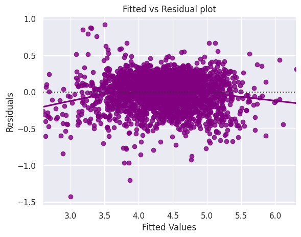

```python
#plotting the fitted values vs residuals

sns.residplot(
    data=data_pred, x="Fitted Values", y="Residuals", color="purple", lowess=True
)
plt.xlabel("Fitted Values")
plt.ylabel("Residuals")
plt.title("Fitted vs Residual plot")
plt.show()
```

Observations

We see no pattern in the plot above. Hence, the assumptions of linearity and independence are satisfied.

#### TEST FOR NORMALITY

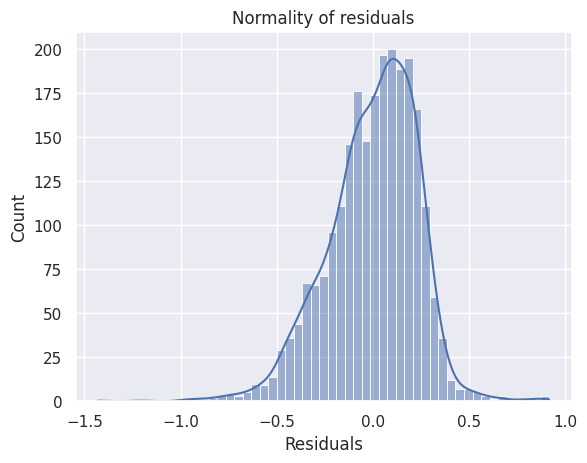

```python
sns.histplot(data=data_pred, x="Residuals", kde=True)
plt.title("Normality of residuals")
plt.show()
```

The histogram of residuals almost has a bell shape structure.

- Let's check the Q-Q plot.

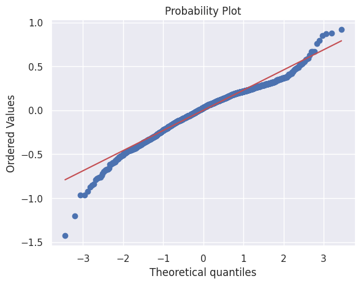

```python
import pylab
import scipy.stats as stats

stats.probplot(data_pred["Residuals"], dist="norm", plot=pylab)
plt.show()
```

The residuals almost follow a straight line.

- Let's check the results of the Shapiro-Wilk test.

```python
stats.shapiro(data_pred["Residuals"])
```

```
ShapiroResult(statistic=0.973078727722168, pvalue=6.314635807815509e-21)
```

Since p-value < 0.05, the residuals are not normal as per the Shapiro-Wilk test. However, based on the distribution plot and Q-Q plot, we can consider the distribution to be a good approximation of the normal distribution. So, the assumption is satisfied

#### TEST FOR HOMOSCEDASTICITY

```python
import statsmodels.stats.api as sms
from statsmodels.compat import lzip

name = ["F statistic", "p-value"]
test = sms.het_goldfeldquandt(data_pred["Residuals"], x_train5)
lzip(name, test)
```

```
[('F statistic', 1.059321586310453), ('p-value', 0.16300771308422282)]
```

- since p-value > 0.05, the residuals are homoscedastic.
- So, the assumption is satisfied.

## Final Model

```python
olsmodel_final = sm.OLS(y_train, x_train5).fit()
print(olsmodel_final.summary())
```

```
                              OLS Regression Results
=================================================================================
Dep. Variable:     normalized_used_price   R-squared:                       0.841
Model:                               OLS   Adj. R-squared:                  0.838
Method:                    Least Squares   F-statistic:                     279.4
Date:                   Fri, 21 Jul 2023   Prob (F-statistic):               0.00
Time:                           21:23:54   Log-Likelihood:                 96.424
No. Observations:                   2417   AIC:                            -100.8
Df Residuals:                       2371   BIC:                             165.5
Df Model:                             45
Covariance Type:               nonrobust
=========================================================================================
                            coef    std err          t      P>|t|      [0.025      0.975]
-----------------------------------------------------------------------------------------
const                     1.1703      0.059     19.999      0.000       1.056       1.285
screen_size               0.0429      0.002     18.273      0.000       0.038       0.047
main_camera_mp            0.0184      0.001     12.470      0.000       0.015       0.021
selfie_camera_mp          0.0128      0.001     11.340      0.000       0.011       0.015
int_memory                0.0001   7.04e-05      1.493      0.136   -3.29e-05       0.000
ram                       0.0226      0.005      4.357      0.000       0.012       0.033
battery                6.884e-07   6.98e-06      0.099      0.921    -1.3e-05    1.44e-05
days_used               5.27e-05   3.12e-05      1.692      0.091   -8.39e-06       0.000
normalized_new_price      0.4329      0.012     34.978      0.000       0.409       0.457
years_since_release      -0.0178      0.005     -3.953      0.000      -0.027      -0.009
brand_name_Alcatel        0.0176      0.031      0.564      0.572      -0.044       0.079
brand_name_Asus           0.0313      0.031      1.011      0.312      -0.029       0.092
brand_name_BlackBerry    -0.0286      0.060     -0.478      0.633      -0.146       0.089
brand_name_Celkon        -0.0325      0.056     -0.577      0.564      -0.143       0.078
brand_name_Coolpad        0.0404      0.063      0.640      0.522      -0.083       0.164
brand_name_Gionee         0.0466      0.045      1.031      0.303      -0.042       0.135
brand_name_Google        -0.0222      0.077     -0.289      0.772      -0.172       0.128
brand_name_HTC         7.902e-06      0.031      0.000      1.000      -0.061       0.061
brand_name_Honor          0.0224      0.032      0.709      0.478      -0.040       0.085
brand_name_Infinix        0.1112      0.086      1.294      0.196      -0.057       0.280
brand_name_Karbonn        0.0954      0.058      1.655      0.098      -0.018       0.208
brand_name_LG            -0.0060      0.026     -0.228      0.820      -0.058       0.046
brand_name_Lava           0.0292      0.052      0.568      0.570      -0.072       0.130
brand_name_Lenovo         0.0545      0.027      2.037      0.042       0.002       0.107
brand_name_Meizu          0.0098      0.042      0.235      0.814      -0.072       0.092
brand_name_Micromax      -0.0283      0.032     -0.882      0.378      -0.091       0.035
```

[output cut: 16 more lines]

```
os_Windows               -0.0182      0.046     -0.399      0.690      -0.108       0.071
os_iOS                   -0.0295      0.048     -0.620      0.535      -0.123       0.064
4g_yes                    0.0404      0.016      2.538      0.011       0.009       0.072
5g_yes                   -0.0446      0.032     -1.398      0.162      -0.107       0.018
==============================================================================
Omnibus:                      206.786   Durbin-Watson:                   1.912
Prob(Omnibus):                  0.000   Jarque-Bera (JB):              373.100
Skew:                          -0.595   Prob(JB):                     9.60e-82
Kurtosis:                       4.512   Cond. No.                     7.87e+04
==============================================================================

Notes:
[1] Standard Errors assume that the covariance matrix of the errors is correctly specified.
[2] The condition number is large, 7.87e+04. This might indicate that there are
strong multicollinearity or other numerical problems.
```